# 16. Clever stop signs and audio

# Communications Department responsibility

The responsibility of the communications department is to make sure the correct text appears on the onboard sign that announces the name of the next stop, and the correct audio plays. This information is specific not only to each stop, but each stop on each variant of a route.

# What to announce

The actual information in the stop sign and the stop announcement should be basically the same, but while the sign text is taken literally from the file that is provided, the audio is actually a tag (like a file name). The tag usually, but doesn’t always, match what’s recorded (and is sometimes misspelled or has other weirdness). Unfortunately there is no way for anyone at AC Transit to rename audio tags, or download the audio and re-upload it with a new tag, although supposedly people at Clever can do this.

The information for each stop should be as follows:

- The first stop on each variant should have no content (not be announced).
- The second stop on each variant should have the full name of the stop announced.
- Subsequent stops should omit the name the street the bus is on, unless that street has changed since the last announcement (generally, if the bus has turned).
- The last stop should have “End of Line” added.[^1]

# CleverWorks process

There’s a user interface in the CleverWorks system that allows modification of the sign text and selected audio for each stop. I won’t be going into that. It’s not particularly difficult to do, but it is very slow and tedious.

Editing the stop sign and audio information in a more efficient way begins with exporting the Stop Sign Text/ Audio file.

[figure not shown]

This will result in a file called “MA_Stop_Sign_Text_Audio_AC TRANSIT_2022-06-27T11.54.csv”, where the date and time part will change.

This is a a comma-separated values file. If one is careful to make sure Excel imports all the columns as “Text” format and not “General” (using the “Text Import Wizard”), one can edit it in Excel, save changes, and the re-upload it into CleverWorks.

This is almost certainly the best way to do this without writing any code. For a typical new variant, where you have one or two stops that change but the rest of the pattern remains the same as a previous variant, it can be pretty easy to copy and paste the entries from the old pattern to the new one, make the few changes that are necessary, and re-upload it.

For completely new routes or new variants, though, it’s a pain to go through and figure out whether the street name should be announced or not. Also, it requires extra work if a change is made to a stop name. This is a really good candidate for automation.

The way I chose to do it was to generate the full audio, each time, from entries in the FileMaker database.

# FileMaker database annunciation data

## The ”Stops_Neue” table

There are several fields in this table referring specifically to announcements.

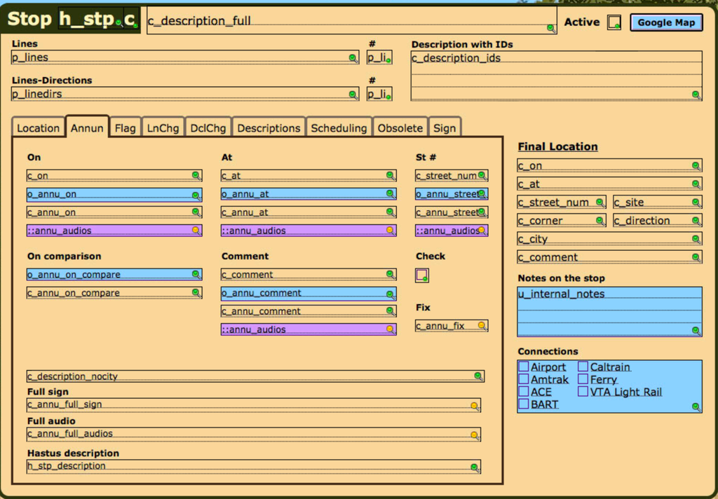

Most of the values start with the general values found in the “Location” tab: c_on, c_at, c_comment, c_street_num. However, sometimes those need to be different on the signs, and data can be entered into o_annu_on, o_annu_at, o_annu_street_num, and o_annu_comment to do that where necessary.

To see whether a stop has the same “on street” as the one before, the program usually compares the “c_annu_on” values. However, the system can be told that something else should actually be used for that comparison, by entering a value in o_annu_on_compare.

To give a hint at what those signs and audios will look like, the “Full sign” and “Full audio” is shown on this screen. However, that assumes that this is the first stop on a street; it doesn’t, here, attempt to remove the “on street”. That can’t be done in FileMaker alone.

## The “annu” table

There “annu” table is used to associate the text on the sign (the field “annu_sign_text”) with the audio file in CleverWorks that represents that text (annu_audios).

The same audio file can be used for two different pieces of text, so “Glen Ave.” and “Glenn Ave.” use the same audio file.

In some cases, a single piece of sign text is represented by multiple audio files, so these are included, in comma-separated value format, in the annu_audios field (e.g., the sign “Thomas L. Berkley Way (20th St.) “ is represented by two audio files: “Thomas_L_Berkley_Way” and “20th St”).

# Running the program

Running “actium.pl stopannu -s w22” (or whatever the signup is) will read the latest “MA_Stop_Sign_Text_Audio…” file in the “cleverworks” folder in the signup folder, and create a new file in the same format, suitable for importing into Cleverworks, called signaudio_import.csv.

If during the run, the computer program finds signs that do not have an equivalent audio file entry (that is, there’s no entry in the annu table for it), it will display this on screen in the terminal window, and also leave the value “UNDEF” in the signaudio_import.csv file. One should open up the signaudio_import.csv file and look for values of “UNDEF”, and then fix the values in the FileMaker database associated with the sign text – either by changing the sign text to something that has an audio file entry, or adding a new audio file entry corresponding to that sign text.

Once the program has run and generated no “UNDEF” entries left, the file is done, and can be imported into CleverWorks. You have to import the file in the Import Attributes screen under the “Import” tab, and then and then accept all the changes in “Attribute Updates”, also under the “Import” tab.

# Adding audio files

If a piece of text has no audio file in the “annu” table, the easiest thing to do is just to add a new entry, and just put the text in twice. When the file is uploaded into CleverWorks, assuming there’s no existing entry in the audio inventory by that name, it will create a new entry. The request can then be sent to Clever Devices to have their audio talent make a recording of it. (Sometimes I’ve sent a recording of my own voice saying the words to the talent, just to clarify any ambiguous spellings.)

There are a lot of audio files in the CleverWorks inventory, but I could only add those that were actively associated with a stop or route to the “annu” table in FileMaker. There may already be an audio recording that says the same thing as your new text. You can search the existing inventory to see if any file names seem to match.

# Incomplete projects

Some stops have additional points of interest that should be announced, possibly only on some lines. I had planned to add a field that would allow additional announced comments, also allowing the user to specify lines or line-direction combinations that the announcement would go on.

One prominent example is Highland Hospital, an important landmark. The closest stop on Line 96 is at a shared stop with Line 62, but Line 62 has a much better stop. Highland Hospital should be announced there on Line 96 but not Line 62.

The 19th and 12th Street BART stations are other examples, where not every line stops at every stop. The best stop for 19th St. BART on Line 72 northbound might be at 17th St., but Line 72R doesn’t stop there, so the announcement needs to be made elsewhere.

This capability was never added.

# Future

Specifying CleverWorks data manually is extremely tedious and time-consuming, and worse, error-prone. Computers are much better than people at keeping track of when streets change or when “End of Line” should be added. Combining this with a facility for specifying the names should be a project that IT should take on as part of its work on CleverWorks.

[^1]: I’ve been wondering if this should be replaced with different language – “Last stop”? -- but haven’t done anything about it yet. I’m not sure why the current language was chosen.